# Final Project Summary

Nino Koci

2025-4-29

## Background

> The Dinaric lynx is a subspecies of the Eurasian lynx, one of the most prominent predators in Europe. It inhabited the areas of northern Yugoslavia, namely Croatia, Slovenia, and Bosnia and Herzegovina. However, its numbers drastically reduced in the 20th century following rapid industrialization in the area and human activity, and by the mid-20th century, the subspecies population had all gone extinct. The extinction of the Dinaric lynx raised concerns as it was a significant loss of one of the main predator populations in the region. An effort was made to reintroduce the lynx population into its former range by transplanting a healthy population into the Dinaric Alps. In 1973, six equal male and female Carpathian lynx from Slovakia were captured and released in Slovenia.[6,8]

> Initially, the newly introduced Dinaric lynx population performed relatively well and reached the range of its extinct predecessor. However, in recent years, it has been revealed that the lynx population has been suffering from increasing rates of inbreeding depression.[6,8] It is not easy to ascertain what specific factors led to the rise of inbreeding. One theory stipulates that the randomly chosen may have been related, such as a mother and son duo.[6] This could have created a founder effect where genes from these two individuals may have been more prevalent, like what happened to the Isle Royale wolf population following a population bottleneck.[7] Similarly, the newly reintroduced Carpathian Slovak lynx may have come from a large, healthy population. Still, after experiencing a bottleneck-like event like in the Isle Royale wolf population, they most likely carried over several deleterious alleles that became fixed into the population following inbreeding.[6] Human activity is also a key factor in the decline of the population.[8] As such, the population experiences a decrease through human activity and then experiences the effects of inbreeding that could have originated from a founder population.

> In recent years, attempts have been made to ameliorate the inbreeding depression of the Dinaric lynx using a genetic rescue program. Previous genetic rescue attempts sought to revitalize a population suffering from inbreeding depression by introducing new members with beneficial mutations and increasing the population’s genetic diversity to reduce homozygosity; a method implemented remarkably well in the Florida Panther rescue.[2,6] A project from 2019 to 2023 has reinforced the current Dinaric population with around 12 Carpathian lynx.[3] The project expects that introducing new individuals will increase the rate of beneficial gene flow within the population by reducing the homozygosity between individuals. Though the study has concluded, the results are still too early to determine whether reinforcement succeeded.

> A 2025 study from Pazhenkova et al. decided to conduct genome-wide testing for the lynx population based on 19 microsatellites and one sex-linked marker to create a model that would simulate the relative fitness of the Dinaric lynx from 1973 to 2019 and then simulate the effect the 2019-2024 reinforcement will have on the population. Alongside modeling the current population, they found that although reinforcement successfully reduced inbreeding depression, it must be done persistently, as it would increase within the population. To address this issue of repeated reinforcement, the team investigated the ideal number of individuals and the itinerary for reintroducing new species members.[6]

> For this project, we will attempt to recreate the study results from Pazhenkova et al. using the Messer Lab Software SLiM 5.0. We expect to leverage the software to recreate the model’s Figures 3 and 4 through our code. Assuming reinforcement is unsuccessful, an alternative method is reconnecting lynx populations across the Balkan Peninsula. As such, we will attempt to use our SLiM code to create a migration-based model to bring other nearby populations of Eurasian lynx into contact with the Dinaric lynx as an alternative to increasing gene flow via reinforcement. This means getting the population from the Dinaric mountains in Croatia and Slovenia to migrate and exchange genes with their Albania, Kosovo, Macedonia, and Serbia neighbors. By attempting to connect the populations of lynxes in the Balkan peninsula, the gene flow may be such that constant reinforcement may not be necessary.

## Methods

#### Part 1: Reintroduction of the population

> The initial run will focus on recapturing Figure 3 and Figures 4a and 4c in Pazhenkova et al.[6] We will initialize the mutations within the genome by introducing one neutral, half-dominant mutation that occupies ¾ of the genome, and a recessive Gaussian (‘g’) mutation that is mildly deleterious in homozygotes with a low standard deviation (0.1). Our recessive deleterious allele is harmful but not lethal enough to kill homozygotes. The mutation rate(μ) was estimated via the population’s general nucleotide diversity (π) value from Lucena-Perez et al. Figure S16 (3.5e-4) and the average census size (N = 28) from Pazhenkova et al, and to calculate it, we use the formula π = Nx4xμ.[4,6] In our calculations, the μ was around 3.0e-6; however, on trial, we found that 4.0e-6 was a better μ as it gave the population a π value around 3.5e-4 within the early populations.

> The genomic element was capped at 10,000 nucleotides, around the size of a gene. The reason for doing so was that we wanted our model to be about a deleterious mutation that causes inbreeding depression within a few generations. A large genome corresponding to the lynx’s one would have made the mutations more harmful, as 25% of the genome is dangerous. As such, we are only attributing the deleterious mutations to one gene.

> For our initial run, we would like to model the 50 generations of the initial Slovak population before introducing a bottleneck-like event to simulate the transplantation of individuals into the Dinaric mountains. We would then run for a few generations, around 5, and observe the effective population change and inbreeding. However, we found that the 50-generation/ticks simulation became more unfeasible with only five generations/ticks since the mutations would not embed. As such, we will change our model to include a year/ticks assumption where 1 year is one tick in SLiM. This will allow us to fix the mutations within the population better. Thus, it would enable us to simulate around 2000 ticks, given our new assumption. However, after many tries, we saw that the mutations became more unpredictable and that we would rather have the Slovak population undergo a brief number of ticks before the bottleneck. Therefore, it was decided that the original Slovak population would only run for 50 years/ticks or around five generations.

> The next step we added was immigration between the Slovak and Romania’s other large Carpathian lynx population. Both these populations will migrate between each other to allow gene flow, keeping the Slovak pop healthy before the transplantation at 50 ticks/year. We kept the original Slovak and Romanian populations at a reasonable census based on their total population in the 2000s.[10] To find our effective population sizes, we used prior data to find the population sizes. Then we divided by 5 to find the census population per generation, as seen in Pazhenkova et al.’s method of dividing the 139 population of the Dinaric lynx into around 28 individuals per generation.[6] We ended up guessing a total Slovak population of 550 and a total Romanian one of 2400; we chose higher values than the source to ensure that these populations are at ideal maximum conditions for effective gene flow. Migration rates were based on a measured guess of the population sizes and the distance between them.

> The new Dinaric lynx population was transformed from the previous Slovak one after the initial 50 years/ticks. We initially tried to set it to 6 individuals. Still, the simulation would not yield satisfactory results even after putting the population in the average census of Pazhenkova et al. Therefore, we scrapped the idea and split the population into 28 individuals. This allowed us to have a consistent population size for the transplantation based on the census. Finally, we will run the first simulation for 100 years/ticks to ensure we capture the initial 50-year run in Figure 3 and the subsequent 40 years in Figures 4a and 4c of Pazhenkova et al.[6]

> To reproduce the figures, we must measure the effective population (Ne) and the reintroduced population’s effective inbreeding (Fe). Ne will be calculated as π/4*μ, with π calculated via the built-in SLiM function calcPi(p1.haplosomes). Fe will be calculated via the Ht over cap Ho, from Frankham, Ballou, and Briscoe, pp. 267-268. Ht, or the current heterozygosity, will be calculated via the function calcHeterozygosity(p1.haplosomes). Ho is the population’s original heterozygosity, and we will use the aforementioned π value of 3.5e-4 as our baseline heterozygosity, as we assume that heterozygosity ≈ π. We will use the functions feature of SLiM to calculate both Ne and Fe. The Ne and Fe values, alongside the population’s π for every tick and fitness, will be added into a SLiM LOG stand-in function, where we return all our measured values from 50 years/ticks to 150 years/ticks, resulting in an Excel CSV file. The Ne, Fe, and Fitness results will be graphed over the cycles in Google Sheets and then edited via Adobe Illustrator into the figures in this article.

### Part 2: Reinforcement of the population following inbreeding

> In this portion of the code, we will reinforce the inbred population by reintroducing new individuals to recreate Figures 4b and 4c from Pazhenkova et al. We will keep our original code from part one, with a few modifications. Namely, we will use a short migratory event from the Romanian and Slovak populations, which allowed them to migrate, exchange gene flow, and introduce them to the inbred population we simulated in the reintroduction model. The short migration event will start from tick 100-105 years/ticks to reintroduce the individuals, roughly emulating the time from 2019 to 2023. We have made it so that the migration event introduces roughly 15 new individuals within this time frame, replicating the 2019-2024 reinforcement project. This new simulation will collect the data from 50 years/ticks to 160 years/ticks, relating the period from 1973 until 2080, with 2080 being the last year in Figures 4b and 4c from Pazhenkova et al.[6]

### Part 3: Alternative to Reinforcement via expanded migrations

> Unlike in the reinforcement model, we will focus on a broader genetic rescue project where we will want to connect different populations to the Dinaric lynx population so that we may allow gene flow and potentially save them from inbreeding. Our assumption about the model is that the populations will self-migrate with limited human intervention, rather than requiring transplantation. We will still use the code we established in Part 1, as we have already established the gene flow between the Slovak and Romanian populations. We will continue the process by adding the lynx populations from eastern Serbia and the Sharr mountain population (Macedonia, Albania, and Kosovo) based on Figure 2 from Pazhenkova et al, to introduce greater gene flow in the region.[9,10] The Serbian population will act as an intermediary because the Romanian and Slovak populations are geographically isolated from the Dinaric and Sharr groups. We will use the census population method and the migration rate method we used in the reintroduction model to establish the initial populations and the migration rates between the populations. Based on our sources, the total population of Balkan lynx and Serbian Carpathian lynx will be 50.[5,10] Finally, we will allow the SLiM model to collect the data from 50 years/ticks to 160 years/ticks so that we may compare these results with those from the reintroduction model.

## Results

### Reintroduction model

[figure not shown]

> The results of the reintroduction model show that the effective population starts small and peaks at around 25 years/ticks after the start, as seen in Figure 1a. Afterwards, the effective population continues to decline until it begins to rise again after around 130-140 ticks after the beginning.

> Finally, the population’s fitness is on a downward trajectory and seems to decrease every year/tick after the start.

### Reinforcement model

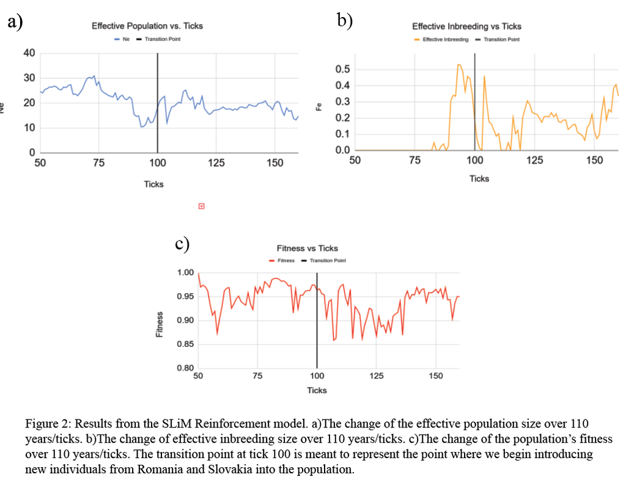

> The results of the reinforcement model in Figure 2a show that the effective population starts small and peaks at around 25 years/ticks after the start. Afterward, the effective population continues to decline until it begins to rise again after around 60-75 ticks after the beginning, before it decreases yet again.

> The effective inbreeding increases after around 45 years/ticks after the start and reaches its peak after 50 years/ticks from the beginning, as seen in Figure 2b, like the results from the reintroduction model. We also observe that effective inbreeding decreases around 110-125 years/ticks after the start and then increases again. Finally, the population’s fitness is relatively stable throughout the model’s run.

### Migration model

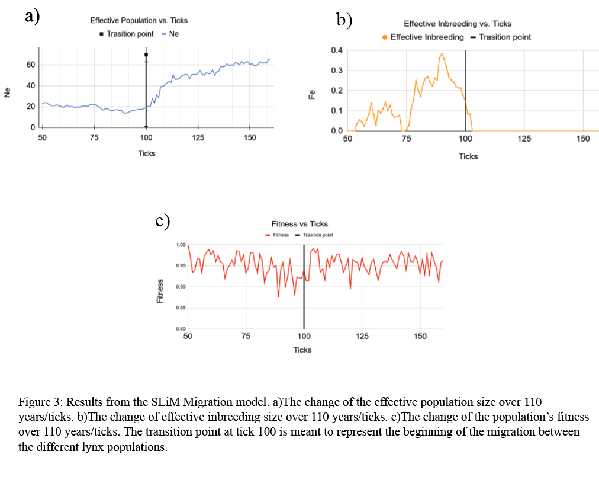

## Discussion

### Reintroduction and Reinforcement SLiM model compared to Pazhenkova et al.

> Figure 1 of this study and Figure 3 of Pazhenkova et al. appear remarkably similar. The effective population in Figure 1a in the study and Figure 3a in Pazhenkova et al. share a similar pattern of an increasing population height peaks at around 25 years/ticks and then decreases over time. The pattern is matched by an increase in effective inbreeding until the end of the first 50 years. If we allow the SLiM simulation for the reintroduction to run for another 50 years/ticks, we will see that the effective population decreases and then slightly gains ground again. This result does match Figure 4a from Pazhenkova et al; however, it does not decrease exponentially, as in the article.[6]

> We noticed a few significant changes when comparing the effective inbreeding results. Figure 1b from the study and Figure 3b from Pazhenkova et al. work somewhat similarly. In both cases, we reach an effective inbreeding of around 0.32-0.33 up to 50 years/ticks. However, in the SLiM model, the inbreeding does not rise until 45 years/ticks. Furthermore, in Figure 4c of the article, the effective inbreeding increases exponentially. In contrast, in the SLiM model, the value of the inbreeding rises to match that of the article before plummeting to low levels.[6]

> In both situations, we see that the SLiM model wants the population to recover after reaching critical levels of inbreeding. Our suspicion of why that occurs could be from the SLiM software allowing for purging detrimental alleles and restabilizing the population. Teixeira and Huber do mention in their work that with increasing depression, we may experience purging of deleterious alleles as a method of surviving.[9] In our case, the population has become less inbred, but the fitness is not improving. This may be evident from the exponentially decreasing fitness in Figure 1c, where we may still see the effective population and inbreeding recovery. Still, the actual population has lost much fitness in re-stabilizing itself.

### Reinforcement SLiM model compared to Pazhenkova et al.

> Reinforcement results for both the SLiM model and those from Pazhenkova et al. remain very similar. In Figure 2a of this study, after 50 years/ticks, we see that the reintroduction of 15 new individuals from Romania and Slovakia over 5 years/ticks significantly improved the effective population, which then goes on to peak at about 60-70 years/ticks from the starting point; these results correspond very well to Figure 4b from Pazhenkova et al., where we see a similar peak and eventual decrease.[6]

> Similarly, effective inbreeding follows the same patterns in Figure 2b as in Figure 4d. It peaks at around 50 years/ticks before decreasing to 60-70 years/ticks and then increasing again. However, the SLiM reintroduction model achieves much higher effective inbreeding before the reintroduction.[6]

> Compared to the previous SLiM reintroduction model, we believe that the SLiM model did not purge any individuals in the population. This could be from the increase in fitness that reinforcement provides, which could explain why the population remained fit. Figure 2c shows that no purging occurred when introducing new beneficial gene flow.

### Migration model vs Reinforcement model

> The migration model’s results match the reinforcement results, with the peak effective population in Figure 3a appearing not to increase as much. However, as we progress, the effective population will still decrease after 50 years/ticks. However, the effective population increases rapidly once we introduce migration into the fold from the neighboring Balkanpopulations. Simultaneously, we see the same pattern with effective inbreeding as in the reintroduction, before the inbreeding plummets following migration.

> These results tell us that the migration scenario was more effective than reinforcement. Migration is more likely to increase gene flow, introduce more random individuals together, and reduce homozygosity in the population. In contrast, in the case of reinforcement, we will need to update our population to avoid repeated inbreeding. Furthermore, a stable migration model helps the Dinaric population and the surrounding Balkan and Carpathian lynx populations have a stable source of gene flow from each other.

## Further expansions to the SLiM models

> Another factor we need to consider is parameter fitting and testing for all the variables we introduced. We can determine optimal parameters for more realistic results by testing different parameters and ranges. Genomic data, migratory data, and the results from the 2019-2024 reinforcement study would go a long way toward providing a set of data that might give us a realistic range of parameters we can attempt to fit into our SLiM models.

> Finally, a new comprehensive census for the lynx population in the region would be a good way of observing how our populations grow or shrink and give us more ideas on the feasibility of the migration model. We need to know if the lynx population will have enough population and range to migrate independently or if it needs transplantation. We assume that the migration model is not reliant on direct human activity, but somewhat indirectly makes the conditions favorable for these populations to migrate independently. Further discussion on finding ways of making deals and shared policy between the Balkan countries to create the conditions for this population to expand would also be needed to undertake such a massive project.